# LC2P: Spaghetti Plots

Laurel Brehm

Making spaghtti plots: prepared for data vis course, march 2019

These data come from Brehm, Jackson, & Miller, BUCLD 2018 proceedings. Note: a lot of data cleaning happened in an earlier file.These are not files fresh from the tracker– they have the IAs and trial ids merged in.

In this experiment, proficient L2 speakers of English (L1 Spanish) hear sentences with occasional agreement anomalies. We ask them to select which image matches the subject of the sentence.

Items are sentences like: “The key to the cabinet(s) literally was/were on the table”  
- noun1, noun2, adverb, verb = timestamps of important words in the sentence (varies by item) - RT = clicking latency for subject selection zeroed to trial onset

These data are from the fixation report output type in eyelink. this is a nice, compact way of storing data– simply combines all the fixations to one pre-defined interest area over time, listing the start and end of the fixation.

To make a spaghetti plot, we need to expand the fixations to list out what’s being looked at every msec, then we’ll do some subtraction to set the zero point to the onset of the verb (=the critical word)

These data also only contain trials of the SPP type (=key to the cabinets were) = a highly plausible error. Sometimes these were answered canonically subject=‘key’ (=Lithead) and sometimes non-literally subject=‘keys’ (=LitHeadFoil)

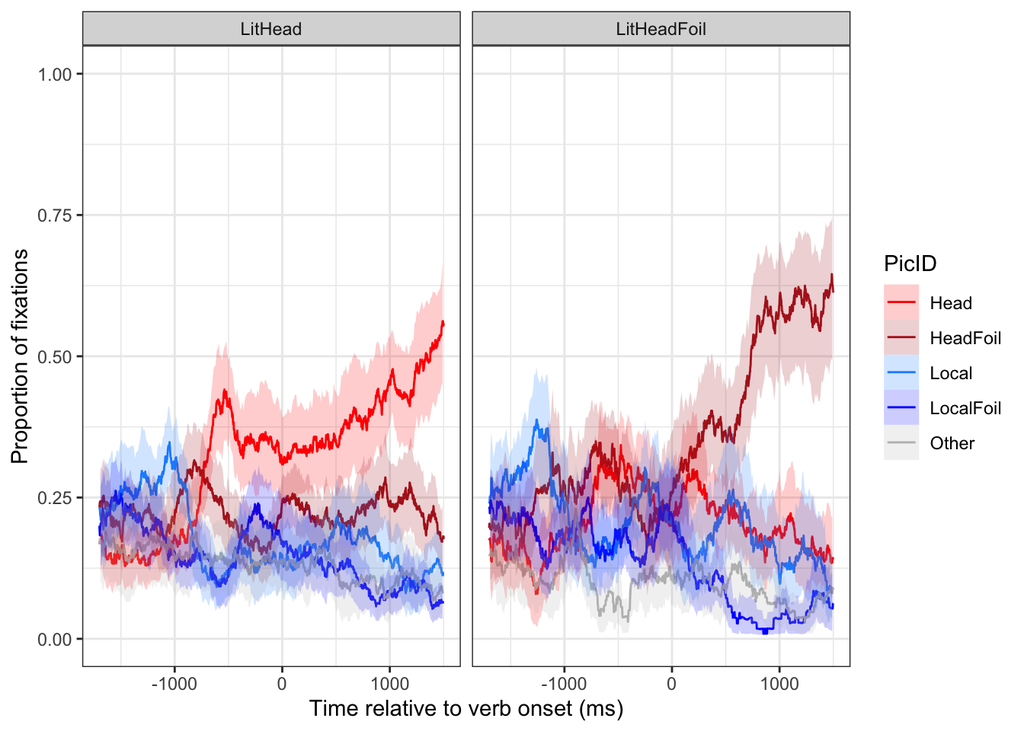

```r
library(reshape)
library(ggplot2)
library(plyr)
##### read in & expand ######
ssSVA1<- read.table("L2Comp-SPP-n28.txt",header=T)

## add row names
ssSVA1$row <- row.names(ssSVA1)

#expand fixations to every msec-- current fix dur to list of fixes in the duration
ssSVA2<-untable(ssSVA1, num=ssSVA1[,19])  #expanding the column current_fix_dur, adding extra rows for every msec of the duration of the fixation
ssSVA2$row2 <- rownames(ssSVA2) ## check whether the row name has been changed by this
ssSVA2$row2<- ifelse(ssSVA2$row2 == ssSVA2$row,paste(ssSVA2$row2,0,sep="."),ssSVA2$row2)  # if it has, take the tabled part of the row name off and assign it to index
index <-  colsplit(ssSVA2$row2,"[.]",names=c("row","index"))[2]
ssSVA2 <- cbind(ssSVA2,index)
ssSVA2$msec <- ssSVA2$CURRENT_FIX_START + ssSVA2$index  ## add the index to the current fix

## now drop out the extra stuff from this computation
ssSVA2$CURRENT_FIX_DUR <- NULL
ssSVA2$CURRENT_FIX_START <- NULL
ssSVA2$CURRENT_FIX_END <- NULL
ssSVA2$row <- NULL
ssSVA2$row2 <- NULL

## initialize zero from critical words
ssSVA2$zN1 <- as.numeric(ssSVA2$msec - ssSVA2$noun1)
ssSVA2$zN2 <- as.numeric(ssSVA2$msec - ssSVA2$noun2)
ssSVA2$zV <- as.numeric(ssSVA2$msec - ssSVA2$verb)
ssSVA2$zC <- as.numeric(ssSVA2$msec - ssSVA2$RT)


####tabulate for spaghetti   ###
### change zero by changing msec variable. zV is zeroed to verb.
ssSVA <- as.data.frame(table(ssSVA2$RespCode,ssSVA2$PicID,round(ssSVA2$zV)))
colnames(ssSVA)<- c("Response","PicID","msec","Count")
ssSVA <- ssSVA[ssSVA$Count!=0,]  ## if using table rather than dplyr, it's gonna be slow

## also count how many observations there are at each msec, to tabulate across
ss2 <- as.data.frame(table(ssSVA2$RespCode,round(ssSVA2$zV)))
colnames(ss2)<- c("Response","msec","TotalCount")
ss2 <- ss2[ss2$TotalCount!=0,]

ssSVA <- merge(ssSVA,ss2) ## this lazy merge will take only the cases where ssSVA occurred
ssSVA$Prop <- ssSVA$Count / ssSVA$TotalCount
ssSVA$msec = as.numeric(as.character(ssSVA$msec))

## downsample to 2 msec
ssSVA <- ssSVA[ssSVA$msec %% 2 == 0,]


### warning: slow. suggested that you read this in instead.
## first, downsample data to every 10 msec
ssSVAe <- ssSVA2[ssSVA2$zV %% 10 == 0,]

## create a list of subs
ssI <- levels(ssSVAe$subj)
N <- length(ssI)
## make a trial counter for merges
is <- seq(1:N)

## draw with replacement many times. I'd normally do 1000.
for (i in 1:1000){
  subj <- sample(ssI,N,replace=T)
  b <- cbind(subj,is)

  b2 <- merge(b,ssSVAe)

  ## do the same tabulation as before
  b3 <- as.data.frame(table(b2$RespCode,b2$zV))
  colnames(b3)<- c("Response","msec","TotalCount")
  b3 <- b3[b3$TotalCount!=0,]

  #overwrite b2
  b2 <- as.data.frame(table(b2$RespCode,b2$PicID,b2$zV))
  colnames(b2)<- c("Response","PicID","msec","Count")
  b2 <- b2[b2$Count!=0,]

  b2 <- merge(b2,b3)
  b2$Prop <- b2$Count / b2$TotalCount
  b2$msec = as.numeric(as.character(b2$msec))

  b2$Iter = i
  ###smush them together
  ifelse(i==1,bs<-b2,bs<-rbind(bs,b2))
}

## trim based on plot choices
bs <- bs[bs$msec > -1700 & bs$msec < 1500,]
## take only trials of interest
bs <- bs[bs$Response=="LitHeadFoil" | bs$Response=="LitHead",]

ssSVAcis <- ddply(bs,.(Response,msec,PicID),summarise, lower=quantile(Prop,.025),upper=quantile(Prop,.975))


## plot spaghetti ###
ggplot(ssSVA[ssSVA$Response=="LitHeadFoil" | ssSVA$Response=="LitHead",],
       aes(x=msec,y=Prop,color=PicID))+
  geom_line()+
  facet_grid(~Response)+
  scale_x_continuous("Time relative to verb onset (ms)", limits=c(-1700,1500))+
  scale_y_continuous("Proportion of fixations", limits=c(0,1))+
  geom_ribbon(data=ssSVAcis, aes(ymin=lower, ymax=upper,x=msec,y=lower,fill=PicID),color="white",lwd=0,alpha=.2)+
  theme_bw()+
  scale_color_manual(values=c("red","firebrick","dodgerblue","blue","gray"))+
  scale_fill_manual(values=c("red","firebrick","dodgerblue","blue","gray"))
```